# Lab 8

Katheryn Moya

11/16/2021

## read in slo_homes.csv

```r
homes <- read_csv(here("data","slo_homes.csv"))
```

## Create a subset with 4 cities

Task: create a subset (called homes_subset) that only contains observations where the city is:

- “San Luis Obispo”
- “Atascadero”
- “Arroyo Grande”
- “Santa Maria-Orcutt”

```r
homes_subset <- homes %>%
  filter(City %in% c("San Luis Obispo", "Atascadero", "Arroyo Grande", "Santa Maria-Orcutt"))
```

### A little exploration

Task: explore the relationship between square footaage and home price (from homes_subset) in a scatterplot.

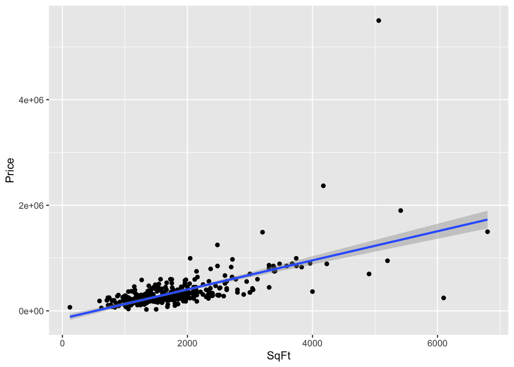

```r
ggplot(data = homes_subset, aes( x = SqFt, y = Price)) +
  geom_point() +
  geom_smooth(method = "lm")
```

### Try a few linear models

Use multiple linear regression to investigate relationships between several predictor variables and home price

Task: create two different permutations of this model: (1) price ~ city, bedrooms, bathrooms, sqft, status (lm1) (2) price ~ city, sqft, status (lm2) (3) try another one (lm3)

```r
lm1 <- lm( Price ~ City + Bedrooms + Bathrooms + SqFt + Status, data = homes_subset)

lm1
```

```
##
## Call:
## lm(formula = Price ~ City + Bedrooms + Bathrooms + SqFt + Status,
##     data = homes_subset)
##
## Coefficients:
##            (Intercept)          CityAtascadero     CitySan Luis Obispo
##               189743.3               -199864.9                 13904.3
## CitySanta Maria-Orcutt                Bedrooms               Bathrooms
##              -260860.8                -61750.0                 36058.6
##                   SqFt           StatusRegular        StatusShort Sale
##                  258.9                208261.9                 -3975.1
```

```r
lm2 <- lm( Price ~ City + SqFt + Status, data = homes_subset)

lm2
```

```
##
## Call:
## lm(formula = Price ~ City + SqFt + Status, data = homes_subset)
##
## Coefficients:
##            (Intercept)          CityAtascadero     CitySan Luis Obispo
##               106333.1               -202157.5                 34525.4
## CitySanta Maria-Orcutt                    SqFt           StatusRegular
##              -275841.3                   245.9                209998.9
##       StatusShort Sale
##                 2282.4
```

```r
lm3 <- lm( Price ~ City + SqFt, data = homes_subset)

lm3
```

```
##
## Call:
## lm(formula = Price ~ City + SqFt, data = homes_subset)
##
## Coefficients:
##            (Intercept)          CityAtascadero     CitySan Luis Obispo
##               161772.5               -234150.8                  9639.5
## CitySanta Maria-Orcutt                    SqFt
##              -325709.6                   250.2
```

```r
# if i wanted SLO to be the reference level:
# use fct_relevel to specify a new reference level

new_homes_subset <- homes_subset %>%
  mutate(City = fct_relevel(City, "San Luis Obispo"))

lm_slo <- lm(Price ~ City + SqFt + Status, data = new_homes_subset)

lm_slo
```

```
##
## Call:
## lm(formula = Price ~ City + SqFt + Status, data = new_homes_subset)
##
## Coefficients:
##            (Intercept)       CityArroyo Grande          CityAtascadero
##               140858.5                -34525.4               -236682.9
## CitySanta Maria-Orcutt                    SqFt           StatusRegular
##              -310366.7                   245.9                209998.9
##       StatusShort Sale
##                 2282.4
```

```r
summary(lm_slo)
```

```
##
## Call:
## lm(formula = Price ~ City + SqFt + Status, data = new_homes_subset)
##
## Residuals:
##      Min       1Q   Median       3Q      Max
## -1087480   -68268     8241    62660  3938242
##
## Coefficients:
##                          Estimate Std. Error t value Pr(>|t|)
## (Intercept)             140858.53   68964.78   2.042  0.04177 *
## CityArroyo Grande       -34525.41   70837.96  -0.487  0.62625
## CityAtascadero         -236682.92   66033.14  -3.584  0.00038 ***
## CitySanta Maria-Orcutt -310366.69   61318.40  -5.062 6.38e-07 ***
## SqFt                       245.93      15.33  16.048  < 2e-16 ***
## StatusRegular           209998.86   49636.98   4.231 2.90e-05 ***
## StatusShort Sale          2282.42   32894.07   0.069  0.94472
## ---
## Signif. codes:  0 '***' 0.001 '**' 0.01 '*' 0.05 '.' 0.1 ' ' 1
##
## Residual standard error: 243100 on 396 degrees of freedom
## Multiple R-squared:  0.5339, Adjusted R-squared:  0.5268
## F-statistic:  75.6 on 6 and 396 DF,  p-value: < 2.2e-16
```

### Explore correlations between quanititative variables

Task: make a subset called homes_quant (starting from homes_subset) that only contains the variables from Price through SqFt

```r
homes_quant <- homes_subset %>%
  select(Price:SqFt)

#find correlations

homes_cor <- cor(homes_quant)
```

### Compare AIC values

```r
AIC(lm1)
```

```
## [1] 11140.72
```

```r
AIC(lm2)
```

```
## [1] 11148
```

lower AIC indicates better balance

### use modelsummary() to return multiple model outputs

```r
modelsummary(list(lm1, lm2, lm3))
```

|  | Model 1 | Model 2 | Model 3 |
| --- | --- | --- | --- |
| (Intercept) | 189743.342 | 106333.118 | 161772.529 |
|  | (64528.622) | (57574.568) | (51172.862) |
| CityAtascadero | −199864.943 | −202157.509 | −234150.800 |
|  | (48835.167) | (49077.007) | (49760.576) |
| CitySan Luis Obispo | 13904.284 | 34525.409 | 9639.524 |
|  | (70820.479) | (70837.962) | (72420.347) |
| CitySanta Maria-Orcutt | −260860.768 | −275841.282 | −325709.568 |
|  | (43072.430) | (42992.765) | (42878.212) |
| Bedrooms | −61749.956 |  |  |
|  | (18674.089) |  |  |
| Bathrooms | 36058.560 |  |  |
|  | (22939.040) |  |  |
| SqFt | 258.909 | 245.934 | 250.217 |
|  | (24.712) | (15.325) | (15.716) |
| StatusRegular | 208261.897 | 209998.857 |  |
|  | (49074.776) | (49636.975) |  |
| StatusShort Sale | −3975.090 | 2282.420 |  |
|  | (32643.175) | (32894.066) |  |
| Num.Obs. | 403 | 403 | 403 |
| R2 | 0.547 | 0.534 | 0.506 |
| R2 Adj. | 0.538 | 0.527 | 0.501 |
| AIC | 11140.7 | 11148.0 | 11167.6 |
| BIC | 11180.7 | 11180.0 | 11191.6 |
| Log.Lik. | −5560.362 | −5566.000 | −5577.815 |
| F | 59.414 | 75.603 | 101.820 |